# Cyclistic Case Study

## Business Objective

**Find answers to the following questions:** How do annual members and casual riders use Cyclistic bikes differently? Why would casual rider buy Cyclistic annual memberships? How can Cyclistic use digital media to influence casual riders to become members?

**Primary stakeholder:** Lily Moreno, Director of Marketing Secondary stakeholders: Cyclistic Executive Team

#### Available data

[Cyclistic provided data](https://divvy-tripdata.s3.amazonaws.com/index.html) - We will look at all 2022 trip data.

## Collect and clean the data

#### Cleaning Log

- Download Cyclistic all trip data from 2022. (This is gathered from 12 separate CSV files.)
- Rename 202209-divvy-publictripdata.csv to 202209-divvy-tripdata.csv to match other filenames
- Remove any potential duplicates in ride_id, primary unique ID field
- Remove any entries with NA values
- Remove rows that contain NA values for missing station data

```r
library(data.table)
library(tidyverse)
library(dplyr)
library(stringr)
library(data.table)
library("lubridate")
```

```r
library(ggplot2)
```

Read each CSV file

```r
trips_03_2022 <- fread("~/cyclistic_2022/202203-divvy-tripdata.csv")
trips_02_2022 <- fread("~/cyclistic_2022/202202-divvy-tripdata.csv")
trips_01_2022 <- fread("~/cyclistic_2022/202201-divvy-tripdata.csv")
trips_04_2022 <- fread("~/cyclistic_2022/202204-divvy-tripdata.csv")
trips_05_2022 <- fread("~/cyclistic_2022/202205-divvy-tripdata.csv")
trips_06_2022 <- fread("~/cyclistic_2022/202206-divvy-tripdata.csv")
trips_07_2022 <- fread("~/cyclistic_2022/202207-divvy-tripdata.csv")
trips_08_2022 <- fread("~/cyclistic_2022/202208-divvy-tripdata.csv")
trips_09_2022 <- fread("~/cyclistic_2022/202209-divvy-tripdata.csv")
trips_10_2022 <- fread("~/cyclistic_2022/202210-divvy-tripdata.csv")
trips_11_2022 <- fread("~/cyclistic_2022/202211-divvy-tripdata.csv")
trips_12_2022 <- fread("~/cyclistic_2022/202212-divvy-tripdata.csv")
```

Each CSV file has 13 variables. Check that all variables are in the right order and have the same format using the glimpse function on each file (January data is shown as an example.)

```r
glimpse(trips_01_2022)
```

```
## Rows: 103,770
## Columns: 13
## $ ride_id            <chr> "C2F7DD78E82EC875", "A6CF8980A652D272", "BD0F91DFF7…
## $ rideable_type      <chr> "electric_bike", "electric_bike", "classic_bike", "…
## $ started_at         <dttm> 2022-01-13 11:59:47, 2022-01-10 08:41:56, 2022-01-…
## $ ended_at           <dttm> 2022-01-13 12:02:44, 2022-01-10 08:46:17, 2022-01-…
## $ start_station_name <chr> "Glenwood Ave & Touhy Ave", "Glenwood Ave & Touhy A…
## $ start_station_id   <chr> "525", "525", "TA1306000016", "KA1504000151", "TA13…
## $ end_station_name   <chr> "Clark St & Touhy Ave", "Clark St & Touhy Ave", "Gr…
## $ end_station_id     <chr> "RP-007", "RP-007", "TA1307000001", "TA1309000021",…
## $ start_lat          <dbl> 42.01280, 42.01276, 41.92560, 41.98359, 41.87785, 4…
## $ start_lng          <dbl> -87.66591, -87.66597, -87.65371, -87.66915, -87.624…
## $ end_lat            <dbl> 42.01256, 42.01256, 41.92533, 41.96151, 41.88462, 4…
## $ end_lng            <dbl> -87.67437, -87.67437, -87.66580, -87.67139, -87.627…
## $ member_casual      <chr> "casual", "casual", "member", "casual", "member", "…
```

Create a single dataset using rbind function.

```r
cyclistic_trips_2022 <- rbind(trips_01_2022,
                              trips_02_2022,
                              trips_03_2022,
                              trips_04_2022,
                              trips_05_2022,
                              trips_06_2022,
                              trips_07_2022,
                              trips_08_2022,
                              trips_09_2022,
                              trips_10_2022,
                              trips_11_2022,
                              trips_12_2022)
```

Eliminate any potential duplicates in ride_id. This is primary unique ID.

```r
cyclistic_trips_2022 %>%
  distinct(ride_id, .keep_all = TRUE)
```

[output not shown]

[output cut: 33 more lines]

Find and remove any entries with NA values

```r
sapply(cyclistic_trips_2022, function(x) sum(is.na(x)))
```

```
##            ride_id      rideable_type         started_at           ended_at
##                  0                  0                  0                  0
## start_station_name   start_station_id   end_station_name     end_station_id
##                  0                  0                  0                  0
##          start_lat          start_lng            end_lat            end_lng
##                  0                  0               5858               5858
##      member_casual
##                  0
```

```r
# Entries with NA value for end_lat and end_lng found. All end station data is also blank.
na_rows <- subset(cyclistic_trips_2022, is.na(cyclistic_trips_2022$end_lat))
# Remove entries with NA values
cyclistic_trips_2022_clean <- na.omit(cyclistic_trips_2022)
```

Check for any possible unexpected results in category columns. Confirm “casual” and “member” are the only two options in the member_casual column

```r
unique(cyclistic_trips_2022_clean$member_casual)
```

```
## [1] "casual" "member"
```

See all rideable type options

```r
unique(cyclistic_trips_2022_clean$rideable_type)
```

```
## [1] "electric_bike" "classic_bike"  "docked_bike"
```

## Prepare data for analysis

Create ride_length column that shows time elapsed between when the ride started and ended.

```r
cyclistic_trips_2022_clean$ride_length <- difftime(cyclistic_trips_2022_clean$ended_at, cyclistic_trips_2022_clean$started_at)
range(cyclistic_trips_2022_clean$ride_length)
```

```
## Time differences in secs
## [1] -621201 2061244
```

Convert ride_length into hours and minutes

```r
cyclistic_trips_2022_clean = cyclistic_trips_2022_clean %>%
  mutate(hours = hour(seconds_to_period(cyclistic_trips_2022_clean$ride_length)),
         minutes = minute(seconds_to_period(cyclistic_trips_2022_clean$ride_length)),)
```

Add date, month, and day of the week columns

```r
cyclistic_trips_2022_clean$date <- as.Date(cyclistic_trips_2022_clean$started_at)
cyclistic_trips_2022_clean$month <- format(as.Date(cyclistic_trips_2022_clean$date), "%m")
cyclistic_trips_2022_clean$day_of_week <- format(as.Date(cyclistic_trips_2022_clean$date), "%A")
```

Remove entries with a negative trip lengths and all docked bikes. Docked bikes have been taken out of circulation so we remove them from our analysis.

```r
trip_data = cyclistic_trips_2022_clean[!(cyclistic_trips_2022_clean$rideable_type == "docked_bike" | cyclistic_trips_2022_clean$ride_length<0),]
```

Remove any rows with empty string for the start_station_name, end station, or trip id

```r
trip_data = trip_data[!trip_data$ride_id=="",]
trip_data = trip_data[!trip_data$start_station_name=="",]
trip_data = trip_data[!trip_data$end_station_name=="",]
```

## Analyze the data

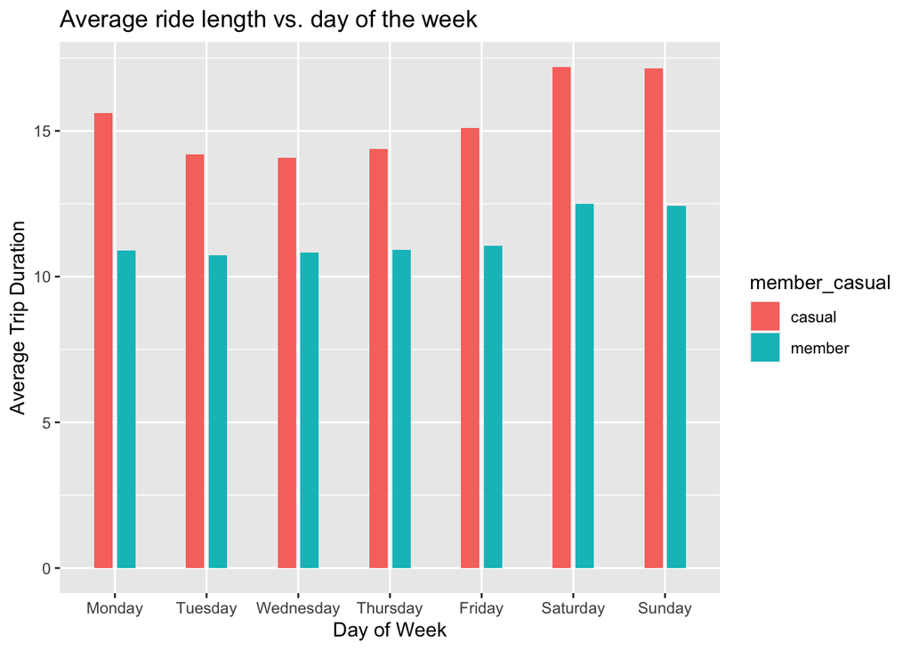

```r
trip_data$day_of_week <- factor(trip_data$day_of_week, levels = c("Monday", "Tuesday", "Wednesday", "Thursday", "Friday","Saturday", "Sunday"))

#Average ride length vs. day of the week
trip_data %>%
  group_by(member_casual, day_of_week) %>%
  summarise(average_duration = mean(minutes), .groups = "drop") %>%
  ggplot(aes(x = day_of_week, y = average_duration, fill = member_casual)) +
    geom_col(width = 0.4, position = position_dodge(width = 0.5)) +
  labs(title = "Average ride length vs. day of the week", x = 'Day of Week', y = 'Average Trip Duration')
```

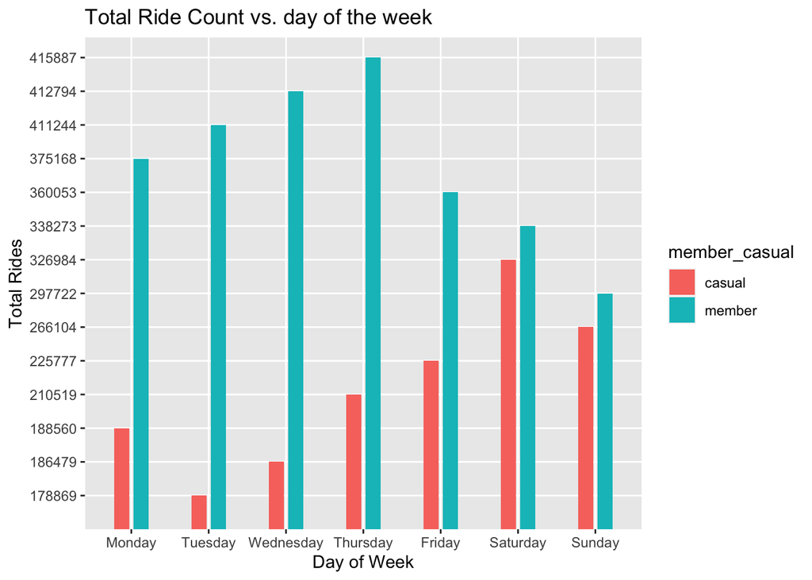

```r
#Total Ride Count vs. day of the week
trip_data %>%
  group_by(member_casual, day_of_week) %>%
  summarise(number_of_rides = n(), .groups = "drop") %>%
  ggplot(aes(x = day_of_week, y = format(number_of_rides, scientific = FALSE), fill = member_casual)) +
  geom_col(width = 0.4, position = position_dodge(width = 0.5)) +
  labs(title = "Total Ride Count vs. day of the week", x = 'Day of Week', y = 'Total Rides')
```

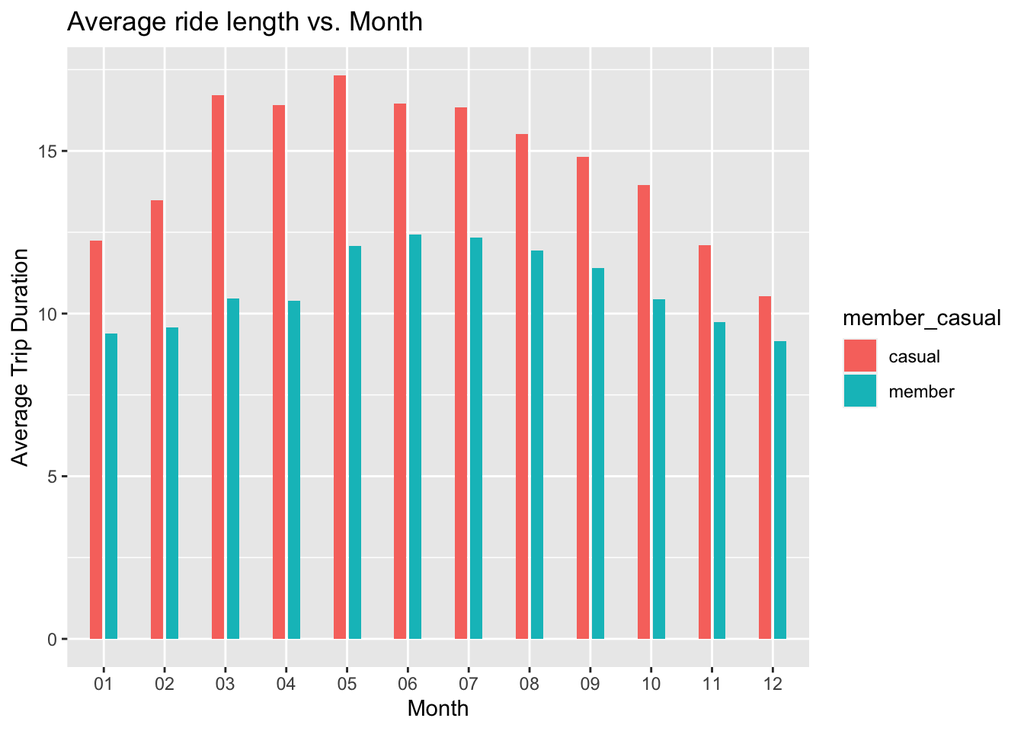

```r
# AVG by month
trip_data %>%
  group_by(member_casual, month) %>%
  summarise(average_duration = mean(minutes), .groups = "drop") %>%
  ggplot(aes(x = month, y = average_duration, fill = member_casual)) +
  geom_col(width = 0.4, position = position_dodge(width = 0.5)) +
  labs(title = "Average ride length vs. Month", x = 'Month', y = 'Average Trip Duration')
```

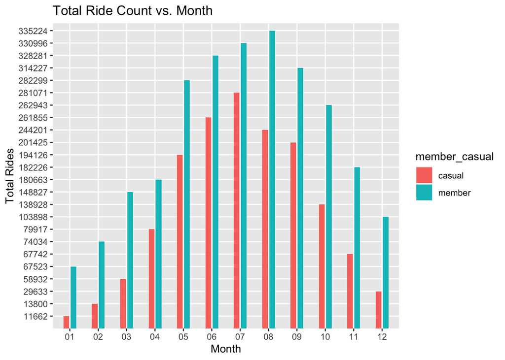

```r
# Total by month
trip_data %>%
  group_by(member_casual, month) %>%
  summarise(number_of_rides = n(), .groups = "drop") %>%
  ggplot(aes(x = month, y = format(number_of_rides, scientific = FALSE), fill = member_casual)) +
  geom_col(width = 0.4, position = position_dodge(width = 0.5)) +
  labs(title = "Total Ride Count vs. Month", x = 'Month', y = 'Total Rides')
```

```r
#Find top 5 start stations by ride count for members and casual customers
station_rides_count <- trip_data %>% group_by(start_station_name, member_casual) %>%
  summarise(total_count=n(), .groups='drop') %>%
  as.data.frame()

top_stations <- station_rides_count %>%                                      # Top N highest values by group
  arrange(desc(total_count)) %>%
  group_by(member_casual) %>%
  slice(1:5)
top_stations
```

```
## # A tibble: 10 × 3
## # Groups:   member_casual [2]
##    start_station_name                 member_casual total_count
##    <chr>                              <chr>               <int>
##  1 Streeter Dr & Grand Ave            casual              43478
##  2 DuSable Lake Shore Dr & Monroe St  casual              23380
##  3 Michigan Ave & Oak St              casual              19589
##  4 DuSable Lake Shore Dr & North Blvd casual              19095
##  5 Millennium Park                    casual              18244
##  6 Kingsbury St & Kinzie St           member              23523
##  7 Clark St & Elm St                  member              20581
##  8 Wells St & Concord Ln              member              19674
##  9 Clinton St & Washington Blvd       member              18828
## 10 Loomis St & Lexington St           member              18252
```

## Conclusions

#### Differences between the bike usage of annual members and casual riders:

- Casual riders rent bikes less often but for longer durations.
- Casual riders use bikes at a higher rate on weekends while members have higher rentals on weekdays
- Bike usage increases through spring and peaks during the summer months

#### Why would casual riders buy Cyclistic annual memberships?

- Casual users seem to use the bikes more for leisure, based on higher rentals on weekends. Cyclistic should consider marketing the benefits of bike commuting to convert more casual riders into members.

#### How can Cyclistic use digital media to inﬂuence casual riders to become members?

- Target marketing campaigns towards neighborhoods surrounding rental stations with highest casual rider usage.
- Promote the benefits of bike commuting, examples are: improved health, environmentally friendly, cost effective transportation
- Use geo-targeted ads to help casual riders find their ideal stations to begin and end their commutes.